# **Predicting Interest Rates Using Natural Language Processing**

By Aakash Sethi, Omar Amin, Sarah Wig, Valentina Espinosa, Christian Jackson

**Aim:** Predicting changes in the Federal Funds Effective Rate from FOMC meeting minutes using natural language processing

**Significance:** Federal Interest Rates, set by the Federal Open Market Committee (FOMC), influence economic activity in the U.S. The FOMC, meets multiple times a year and determines these rates. Rate changes have widespread effects on markets such as real estate, equities, and fixed income. We believe that developing a model that analyzes FOMC meeting minutes for patterns could serve as a valuable leading indicator for investors and economists across various markets.

**Data:** FOMC Meeting Minutes 2019-2022, Federal Funds Effective Rate, Macroeconomic Variables

**Methodology:** Sentiment analysis on FOMC meeting minutes using NLTK and Loughran and McDonald Financial Sentiment Dictionaries to predict interest rate changes

# 1: Data

```python
pip install pdfplumber pandas nltk
```

```python
# Installing a pdfplumber since we're extracting text from pdfs
import os
import pdfplumber
import pandas as pd

def pdf_reader(pdf_path):
    with pdfplumber.open(pdf_path) as pdf:
        text = ''
        for page in pdf.pages:
            text += page.extract_text()
    return text

# Specifying the folder containing the PDFs
pdf_folder = '/home/ctjacksn/Christian/Project/Minutes'

# Getting a list of all PDF files in the folder
pdf_files = [file for file in os.listdir(pdf_folder) if file.endswith('.pdf')]

# Creating an empty list to store data frames for each PDF
dfs = []

# Processing each PDF and creating a data frame
for pdf_file in pdf_files:
    pdf_path = os.path.join(pdf_folder, pdf_file)
    pdf_text = pdf_reader(pdf_path)
    sentences = pdf_text.split('.')
    df = pd.DataFrame({'Sentences': sentences, 'PDF_File': pdf_file})
    dfs.append(df)

# Concatenating all data frames into a single data frame
merged_df = pd.concat(dfs, ignore_index=True)

# Displaying the first few rows of the merged data frame
merged_df.head()
```

|  | Sentences | PDF_File |
| --- | --- | --- |
| 0 | ______________________________________________... | fomcminutes20221214.pdf |
| 1 | m | fomcminutes20221214.pdf |
| 2 | and con-\nPhiladelphia\ntinued on Wednesday, ... | fomcminutes20221214.pdf |
| 3 | m | fomcminutes20221214.pdf |
| 4 | 1\nKartik B | fomcminutes20221214.pdf |

# 2: Sentiment Analysis Using NLTK

```python
import os
import pdfplumber
import pandas as pd
from nltk.sentiment import SentimentIntensityAnalyzer

# This is the function we're using NLTK to conduct sentiment analysis on the text from each PDF
def analyze_sentiment(text):
    sia = SentimentIntensityAnalyzer()
    sentiment_score = sia.polarity_scores(text)
    return sentiment_score['compound']

# Here we are specifying the folder with all of our FOMC Meeting Minutes, and then putting them into an empty list.
# We also ensure that the file has .pdf at the end his isn't super necessary but it's added as cautionary measure.
pdf_folder = '/home/ctjacksn/Christian/Project/Minutes'
pdf_files = [file for file in os.listdir(pdf_folder) if file.endswith('.pdf')]
sentiment_scores = []

# Processing each PDF and performing sentiment analysis
for pdf_file in pdf_files:
    pdf_path = os.path.join(pdf_folder, pdf_file)

    if os.path.isfile(pdf_path):
        pdf_text = pdf_reader(pdf_path)

        # This is where we're calling our analyze_sentiment function
        sentiment_score = analyze_sentiment(pdf_text)
        sentiment_scores.append({'PDF_File': pdf_file, 'Sentiment_Score': sentiment_score})

sentiment_df_nltk = pd.DataFrame(sentiment_scores)
#Now we've created a dataframe with all of the NLTK sentiment scores from each pdf
```

2.2 Associating Scores With PDFs

```python
# This part takes the average sentiment score from each PDF. Reset_index allows to order our PDFs better
aggregated_sentiment_df_nltk = sentiment_df_nltk.groupby('PDF_File')['Sentiment_Score'].agg('mean').reset_index()

# Calling our original dataset with all of our interest rate data. The interest rate data is going to be used to create a forecast/predction.
interest_rate_df_nltk = pd.read_csv('/home/ctjacksn/Christian/Project/FEDFUNDS2019to2022withPDFS.csv')

# Here we are basically associating each average sentiment score with a pdf AND an interest rate. This merged data is now ready for analysis.
merged_data_nltk = pd.merge(aggregated_sentiment_df_nltk, interest_rate_df_nltk, how='inner', left_on='PDF_File', right_on='Associated PDF')

# Displaying the merged data for NLTK
merged_data_nltk
```

|  | PDF_File | Sentiment_Score | DATE | RATE | RATE CHANGE | Associated PDF |
| --- | --- | --- | --- | --- | --- | --- |
| 0 | fomcminutes20190130.pdf | 1.0000 | 2/1/2019 | 2.40 | 0.000000 | fomcminutes20190130.pdf |
| 1 | fomcminutes20190320.pdf | 0.9999 | 4/1/2019 | 2.42 | 0.008333 | fomcminutes20190320.pdf |
| 2 | fomcminutes20190501.pdf | 0.9999 | 5/1/2019 | 2.39 | -0.012397 | fomcminutes20190501.pdf |
| 3 | fomcminutes20190731.pdf | 0.9999 | 8/1/2019 | 2.13 | -0.108787 | fomcminutes20190731.pdf |
| 4 | fomcminutes20190918.pdf | 0.9996 | 10/1/2019 | 1.83 | -0.140845 | fomcminutes20190918.pdf |
| 5 | fomcminutes20191030.pdf | 0.9999 | 11/1/2019 | 1.55 | -0.153005 | fomcminutes20191030.pdf |
| 6 | fomcminutes20191211.pdf | 0.9998 | 1/1/2020 | 1.55 | 0.000000 | fomcminutes20191211.pdf |
| 7 | fomcminutes20200129.pdf | 1.0000 | 2/1/2020 | 1.58 | 0.019355 | fomcminutes20200129.pdf |
| 8 | fomcminutes20200315.pdf | 0.9999 | 4/1/2020 | 0.05 | -0.968354 | fomcminutes20200315.pdf |
| 9 | fomcminutes20200429.pdf | 0.9999 | 5/1/2020 | 0.05 | 0.000000 | fomcminutes20200429.pdf |
| 10 | fomcminutes20200610.pdf | 0.9999 | 7/1/2020 | 0.09 | 0.800000 | fomcminutes20200610.pdf |
| 11 | fomcminutes20200729.pdf | 0.9999 | 8/1/2020 | 0.10 | 0.111111 | fomcminutes20200729.pdf |
| 12 | fomcminutes20200916.pdf | 1.0000 | 10/1/2020 | 0.09 | -0.100000 | fomcminutes20200916.pdf |
| 13 | fomcminutes20201105.pdf | 0.9999 | 12/1/2020 | 0.09 | 0.000000 | fomcminutes20201105.pdf |
| 14 | fomcminutes20201216.pdf | 1.0000 | 1/1/2021 | 0.09 | 0.000000 | fomcminutes20201216.pdf |
| 15 | fomcminutes20210127.pdf | 1.0000 | 2/1/2021 | 0.08 | -0.111111 | fomcminutes20210127.pdf |
| 16 | fomcminutes20210317.pdf | 1.0000 | 4/1/2021 | 0.07 | -0.125000 | fomcminutes20210317.pdf |
| 17 | fomcminutes20210428.pdf | 1.0000 | 5/1/2021 | 0.06 | -0.142857 | fomcminutes20210428.pdf |
| 18 | fomcminutes20210728.pdf | 1.0000 | 7/1/2021 | 0.10 | 0.666667 | fomcminutes20210728.pdf |
| 19 | fomcminutes20210922.pdf | 1.0000 | 10/1/2021 | 0.08 | -0.200000 | fomcminutes20210922.pdf |
| 20 | fomcminutes20211103.pdf | 1.0000 | 12/1/2021 | 0.08 | 0.000000 | fomcminutes20211103.pdf |
| 21 | fomcminutes20211215.pdf | 1.0000 | 1/1/2022 | 0.08 | 0.000000 | fomcminutes20211215.pdf |
| 22 | fomcminutes20220126.pdf | 1.0000 | 2/1/2022 | 0.08 | 0.000000 | fomcminutes20220126.pdf |
| 23 | fomcminutes20220316.pdf | 0.9999 | 4/1/2022 | 0.33 | 3.125000 | fomcminutes20220316.pdf |
| 24 | fomcminutes20220504.pdf | 0.9999 | 6/1/2022 | 1.21 | 2.666667 | fomcminutes20220504.pdf |
| 25 | fomcminutes20220615.pdf | 0.9999 | 7/1/2022 | 1.68 | 0.388430 | fomcminutes20220615.pdf |
| 26 | fomcminutes20220727.pdf | 0.9999 | 8/1/2022 | 2.33 | 0.386905 | fomcminutes20220727.pdf |
| 27 | fomcminutes20220921.pdf | 0.9999 | 10/1/2022 | 3.08 | 0.321888 | fomcminutes20220921.pdf |
| 28 | fomcminutes20221102.pdf | 0.9999 | 12/1/2022 | 4.10 | 0.331169 | fomcminutes20221102.pdf |
| 29 | fomcminutes20221214.pdf | 0.9999 | 1/1/2023 | 4.33 | 0.056098 | fomcminutes20221214.pdf |

2.3 Visualisations

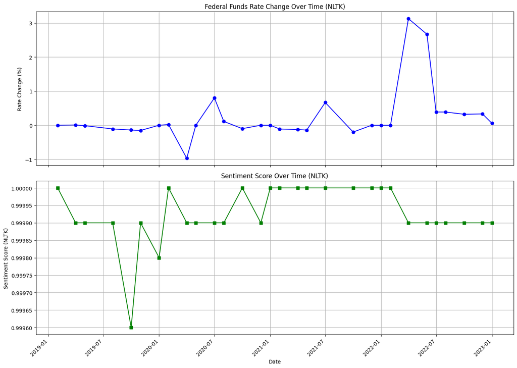

```python
# Before our analysis, we just want to check if there's any indicators of a correlation here between the interest rate change and the sentiment score.
import pandas as pd
import matplotlib.pyplot as plt
import matplotlib.dates as mdates

merged_data_nltk['DATE'] = pd.to_datetime(merged_data_nltk['DATE'])

fig, (ax1, ax2) = plt.subplots(2, 1, figsize=(14, 10), sharex=True)

ax1.plot(merged_data_nltk['DATE'], merged_data_nltk['RATE CHANGE'], marker='o', linestyle='-', color='blue')
ax1.set_title('Federal Funds Rate Change Over Time (NLTK)')
ax1.set_ylabel('Rate Change (%)')
ax1.grid(True)
ax1.xaxis.set_major_locator(mdates.AutoDateLocator())
ax1.xaxis.set_major_formatter(mdates.DateFormatter('%Y-%m'))

ax2.plot(merged_data_nltk['DATE'], merged_data_nltk['Sentiment_Score'], marker='s', linestyle='-', color='green')
ax2.set_title('Sentiment Score Over Time (NLTK)')
ax2.set_xlabel('Date')
ax2.set_ylabel('Sentiment Score (NLTK)')
ax2.grid(True)

plt.setp(ax2.get_xticklabels(), rotation=45, ha="right")

plt.tight_layout()

plt.show()
```

2.4 Predicted Interest Rates

```python
from sklearn.model_selection import train_test_split
from sklearn.linear_model import LinearRegression
from sklearn.metrics import mean_absolute_error

# For our model here we're establishing the sentiment score as the independent variable and the rate change as the dependent variable that we're trying to predict
features_nltk = ['Sentiment_Score']
X_nltk = merged_data_nltk[features_nltk]
y_nltk = merged_data_nltk['RATE CHANGE']

# Splitting the data into training and testing sets, test size and random_state are just chosen based on what we've learned in class
X_train_nltk, X_test_nltk, y_train_nltk, y_test_nltk = train_test_split(X_nltk, y_nltk, test_size=0.2, random_state=0)

# Making predictions on the test set for NLTK
predictions_nltk = LinearRegression().fit(X_train_nltk, y_train_nltk).predict(X_test_nltk)

# Evaluating the model for NLTK. Just an added measure to asses our model.
mae_nltk = mean_absolute_error(y_test_nltk, predictions_nltk)
print("Mean Absolute Error (NLTK):", {mae_nltk})

# Making predictions for 2023
features_2023_nltk = merged_data_nltk.loc[merged_data_nltk['DATE'] == '1/1/2023', 'Sentiment_Score'].values.reshape(-1, 1)
interest_rate_change_2023_nltk = LinearRegression().fit(X_nltk, y_nltk).predict(features_2023_nltk)

print('NLTK Predicted Interest Rate Change in 2023:', interest_rate_change_2023_nltk[0])
```

```
Mean Absolute Error (NLTK): {0.6601581899511518}
NLTK Predicted Interest Rate Change in 2023: 0.24595156269811014
```

2.5 Visualizations With Economic Events

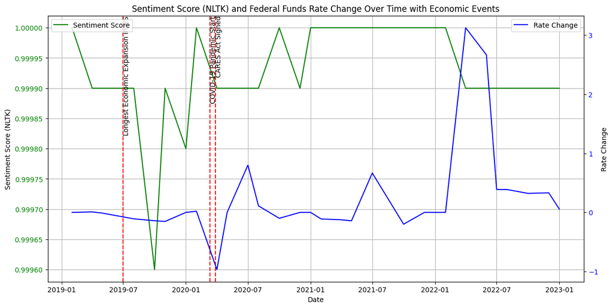

```python
#This chart superimposes major economic events alongside the evolution of the sentiment analysis the interest rates

import matplotlib.pyplot as plt
import matplotlib.dates as mdates

economic_events = {
    'Longest Economic Expansion in US': '2019-07-01',
    'COVID-19 Pandemic Start': '2020-03-11',
    'CARES Act Signed': '2020-03-27',
}

merged_data_nltk['DATE'] = pd.to_datetime(merged_data_nltk['DATE'])

fig, ax1 = plt.subplots(figsize=(14, 7))

ax1.plot(merged_data_nltk['DATE'], merged_data_nltk['Sentiment_Score'], label='Sentiment Score', color='green')
ax1.set_xlabel('Date')
ax1.set_ylabel('Sentiment Score (NLTK)')
ax1.tick_params(axis='y', labelcolor='green')

for event, date in economic_events.items():
    ax1.axvline(pd.to_datetime(date), linestyle='--', color='red')  # Add a vertical line for the event
    ax1.text(pd.to_datetime(date), ax1.get_ylim()[1], event, rotation=90, verticalalignment='top')  # Add text annotation

ax2 = ax1.twinx()
ax2.plot(merged_data_nltk['DATE'], merged_data_nltk['RATE CHANGE'], label='Rate Change', color='blue')
ax2.set_ylabel('Rate Change')
ax2.tick_params(axis='y', labelcolor='blue')

plt.title('Sentiment Score (NLTK) and Federal Funds Rate Change Over Time with Economic Events')
ax1.grid(True)
ax1.legend(loc='upper left')
ax2.legend(loc='upper right')

plt.show()
```

2.6 Correlation

```python
#Over here we are getting the coefficient of the sentiment scores and the interest rates to see how related they are
merged_data_nltk['Abs_Sentiment_Score_NLTK'] = abs(merged_data_nltk['Sentiment_Score'])
merged_data_nltk['Abs_RATE_CHANGE'] = abs(merged_data_nltk['RATE CHANGE'])

correlation_nltk = merged_data_nltk['Abs_Sentiment_Score_NLTK'].corr(merged_data_nltk['Abs_RATE_CHANGE'])

print("The correlation coefficient between the sentiment scores (NLTK) and interest rate changes is:", correlation_nltk)
```

```
The correlation coefficient between the sentiment scores (NLTK) and interest rate changes is: -0.11227650728096511
```

# 3: Sentiment Analysis Using Loughran Mcdonald Model

3.1 Loughran Mcdonald Model

```python
import os
import pdfplumber
import pandas as pd

# Loading the Loughran and McDonald Financial Sentiment Master Dictionary
loughran_mcdonald_master_dict = pd.read_csv('/home/ctjacksn/Christian/Project/Loughran-McDonald_MasterDictionary_1993-2021.csv')

# Performing sentiment analysis using Loughran and McDonald master dictionary
def analyze_sentiment_loughran_mcdonald(text):
    positive_words = set(loughran_mcdonald_master_dict[loughran_mcdonald_master_dict['Positive'] != 0]['Word'].str.lower())
    negative_words = set(loughran_mcdonald_master_dict[loughran_mcdonald_master_dict['Negative'] != 0]['Word'].str.lower())

    tokens = text.lower().split()  # Convert to lowercase and split by whitespace

    positive_count = sum(1 for word in tokens if word in positive_words)
    negative_count = sum(1 for word in tokens if word in negative_words)

    # Calculating sentiment score
    sentiment_score = positive_count - negative_count

    return sentiment_score

# Specifying the folder containing your PDFs
pdf_folder = '/home/ctjacksn/Christian/Project/Minutes'

# Getting a list of all PDF files in the folder
pdf_files = [file for file in os.listdir(pdf_folder) if file.endswith('.pdf')]

# Create an empty list to store sentiment scores for each PDF
sentiment_scores = []

# Processing each PDF and perform sentiment analysis
for pdf_file in pdf_files:
    pdf_path = os.path.join(pdf_folder, pdf_file)

    # Checking if the path is a file
    if os.path.isfile(pdf_path):
        pdf_text = pdf_reader(pdf_path)

        sentiment_score = analyze_sentiment_loughran_mcdonald(pdf_text)

        sentiment_scores.append({'PDF_File': pdf_file, 'Sentiment_Score': sentiment_score})

# Creating a data frame from the sentiment scores
sentiment_df_loughran_mcdonald = pd.DataFrame(sentiment_scores)
```

3.2 Associating Scores With PDFs

```python
#Now, we take our CSV file and associate each rate with a specific pdf file. This will be used to make a prediction based on the sentiment
aggregated_sentiment_df = sentiment_df_loughran_mcdonald.groupby('PDF_File')['Sentiment_Score'].agg('mean').reset_index()

interest_rate_df = pd.read_csv('/home/ctjacksn/Christian/Project/FEDFUNDS2019to2022withPDFS.csv')

# Merging the aggregated sentiment scores with the interest rates based on PDF_File
merged_data = pd.merge(aggregated_sentiment_df, interest_rate_df, how='inner', left_on='PDF_File', right_on='Associated PDF')

pd.set_option('display.max_columns', None)  # Displaying all columns
pd.set_option('display.expand_frame_repr', False)  # Preventing line wrapping

print(merged_data)
```

```
                   PDF_File  Sentiment_Score       DATE  RATE  RATE CHANGE           Associated PDF
0   fomcminutes20190130.pdf            -52.0   2/1/2019  2.40     0.000000  fomcminutes20190130.pdf
1   fomcminutes20190320.pdf           -111.0   4/1/2019  2.42     0.008333  fomcminutes20190320.pdf
2   fomcminutes20190501.pdf            -47.0   5/1/2019  2.39    -0.012397  fomcminutes20190501.pdf
3   fomcminutes20190731.pdf            -58.0   8/1/2019  2.13    -0.108787  fomcminutes20190731.pdf
4   fomcminutes20190918.pdf           -155.0  10/1/2019  1.83    -0.140845  fomcminutes20190918.pdf
5   fomcminutes20191030.pdf           -108.0  11/1/2019  1.55    -0.153005  fomcminutes20191030.pdf
6   fomcminutes20191211.pdf            -94.0   1/1/2020  1.55     0.000000  fomcminutes20191211.pdf
7   fomcminutes20200129.pdf            -28.0   2/1/2020  1.58     0.019355  fomcminutes20200129.pdf
8   fomcminutes20200315.pdf           -168.0   4/1/2020  0.05    -0.968354  fomcminutes20200315.pdf
9   fomcminutes20200429.pdf           -163.0   5/1/2020  0.05     0.000000  fomcminutes20200429.pdf
10  fomcminutes20200610.pdf           -124.0   7/1/2020  0.09     0.800000  fomcminutes20200610.pdf
11  fomcminutes20200729.pdf            -54.0   8/1/2020  0.10     0.111111  fomcminutes20200729.pdf
12  fomcminutes20200916.pdf            -42.0  10/1/2020  0.09    -0.100000  fomcminutes20200916.pdf
13  fomcminutes20201105.pdf            -73.0  12/1/2020  0.09     0.000000  fomcminutes20201105.pdf
```

[output cut: 16 more lines]

3.3 Visualizations

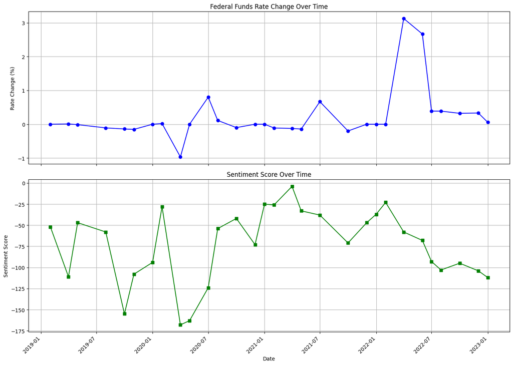

```python
import matplotlib.pyplot as plt
import matplotlib.dates as mdates

merged_data['DATE'] = pd.to_datetime(merged_data['DATE'])


fig, (ax1, ax2) = plt.subplots(2, 1, figsize=(14, 10), sharex=True)


ax1.plot(merged_data['DATE'], merged_data['RATE CHANGE'], marker='o', linestyle='-', color='blue')
ax1.set_title('Federal Funds Rate Change Over Time')
ax1.set_ylabel('Rate Change (%)')
ax1.grid(True)
ax1.xaxis.set_major_locator(mdates.AutoDateLocator())
ax1.xaxis.set_major_formatter(mdates.DateFormatter('%Y-%m'))


ax2.plot(merged_data['DATE'], merged_data['Sentiment_Score'], marker='s', linestyle='-', color='green')
ax2.set_title('Sentiment Score Over Time')
ax2.set_xlabel('Date')
ax2.set_ylabel('Sentiment Score')
ax2.grid(True)


plt.setp(ax2.get_xticklabels(), rotation=45, ha="right")


plt.tight_layout()

plt.show()
```

3.4 Predicting Interest Rates

```python
from sklearn.model_selection import train_test_split
from sklearn.linear_model import LinearRegression
from sklearn.metrics import mean_absolute_error

features = ['Sentiment_Score']
X = merged_data[features]
y = merged_data['RATE CHANGE']  # Target variable

# Splitting the data into training and testing sets
X_train, X_test, y_train, y_test = train_test_split(X, y, test_size=0.2, random_state=0)

# Creating and training the linear regression model
model = LinearRegression()
model.fit(X_train, y_train)

# Making predictions on the test set
predictions = model.predict(X_test)

# Evaluating the model
mae = mean_absolute_error(y_test, predictions)
print(f'Mean Absolute Error: {mae}')

# Making predictions for 2023
features_2023 = merged_data.loc[merged_data['DATE'] == '1/1/2023', 'Sentiment_Score'].values.reshape(-1, 1)
interest_rate_change_2023 = model.predict(features_2023)

print("Predicted Interest Rate Change for 2023:", {interest_rate_change_2023[0]})
```

```
Mean Absolute Error: 0.7241244120334871
Predicted Interest Rate Change for 2023: {-0.0003011343144331824}
```

3.5 Visualisations with Economic Events

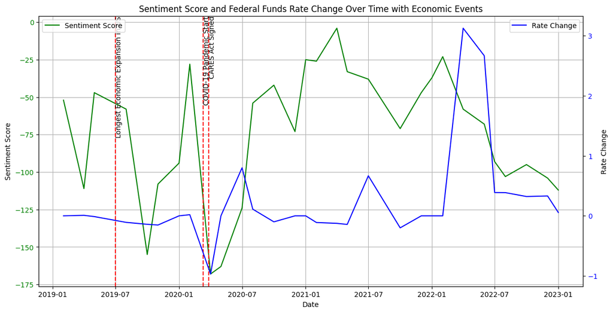

```python
economic_events = {

    'Longest Economic Expansion in US': '2019-07-01',
    'COVID-19 Pandemic Start': '2020-03-11',
    'CARES Act Signed': '2020-03-27',
}

merged_data['DATE'] = pd.to_datetime(merged_data['DATE'])


fig, ax1 = plt.subplots(figsize=(14, 7))


ax1.plot(merged_data['DATE'], merged_data['Sentiment_Score'], label='Sentiment Score', color='green')
ax1.set_xlabel('Date')
ax1.set_ylabel('Sentiment Score')
ax1.tick_params(axis='y', labelcolor='green')

for event, date in economic_events.items():
    ax1.axvline(pd.to_datetime(date), linestyle='--', color='red')  # Add a vertical line for the event
    ax1.text(pd.to_datetime(date), ax1.get_ylim()[1], event, rotation=90, verticalalignment='top')  # Add text annotation


ax2 = ax1.twinx()
ax2.plot(merged_data['DATE'], merged_data['RATE CHANGE'], label='Rate Change', color='blue')
ax2.set_ylabel('Rate Change')
ax2.tick_params(axis='y', labelcolor='blue')


plt.title('Sentiment Score and Federal Funds Rate Change Over Time with Economic Events')
ax1.grid(True)
ax1.legend(loc='upper left')
ax2.legend(loc='upper right')


plt.show()
```

3.6 Correlation

```python
merged_data['Abs_Sentiment_Score'] = merged_data['Sentiment_Score']
merged_data['Abs_RATE_CHANGE'] = merged_data['RATE CHANGE']


correlation = merged_data['Abs_Sentiment_Score'].corr(merged_data['Abs_RATE_CHANGE'])

print("The correlation coefficient between the sentiment scores (NLTK) and interest rate changes is:",correlation)
```

[output not shown]